# HW2

CAN GİZER

5/13/2022

### SETTING WD AND INSTALING REQUIRED PACKAGES

```r
library(ggplot2)
library(forecast)
library(data.table)
library(GGally)
library(ggcorrplot)
library(zoo)
getwd()
```

```
## [1] "/Users/iremgizer/Desktop"
```

```r
setwd("/Users/iremgizer/Desktop")
```

### READING DATA AND MANIPULATING IT

```r
hw2.data<-data.table(read.csv("IE360_Spring22_HW2_data.csv"))
str(hw2.data)
```

```
## Classes 'data.table' and 'data.frame':   32 obs. of  11 variables:
##  $ Quarter                         : chr  "2000_Q1" "2000_Q2" "2000_Q3" "2000_Q4" ...
##  $ UnleadedGasolineSale.UGS.       : int  1128971 1199569 1370167 1127548 1033918 1019754 1209916 1002789 893722 1027252 ...
##  $ RNUV                            : num  0.0146 0.0205 0.0207 0.0163 0.0071 0.0051 0.0041 0.0048 0.0012 0.0032 ...
##  $ X.LPGVehicles.NLPG.             : int  940000 941000 943500 948000 950000 955000 967500 990000 1000000 1001000 ...
##  $ PriceofUnleadedGasoline.PU.     : num  469 459 440 402 412 ...
##  $ PriceofDieselGasoline.PG.       : num  356 345 327 301 306 ...
##  $ X.UnleadedGasolineVehicles.NUGV.: int  4647500 4742876 4840931 4919685 4954754 4980204 5000446 5024693 5030810 5046960 ...
##  $ X.ofDieselGasolineVehicles.NDGV.: num  282 284 287 288 288 ...
##  $ GNPAgriculture                  : int  1040173 1760460 6974808 3267125 1004528 1449357 5890424 1940854 832953 1419764 ...
##  $ GNPCommerce                     : int  3483132 4525451 5915204 4929778 3418387 4359831 5925547 4559190 3374849 4363782 ...
##  $ GNPTotal                        : int  18022686 21797130 30050207 24480153 15832648 20296918 28017963 22656812 18393446 20382635 ...
##  - attr(*, ".internal.selfref")=<externalptr>
```

```r
colnames(hw2.data) <- c("Quarter","UGS","RNUV","NLPG","PU","PG","NUGV","NDGV","GNPA","GNPC","GNP")
hw2.data$Quarter <- as.yearqtr(hw2.data$Quarter,"%Y_Q%q")
```

CSV data has been taken as a data table, appropriate table names are given. For their explanations, the viewer may check below. Quarters have also been taken as dates to easier workflow. UGS: Unleaded gasoline sale in a given quarter, RNUV: An index indicating the rate of new unleaded gasoline using vehicles being added to the traffic in a quarter, NLPG: Number of LPG using vehicles in the traffic, PU: Average price (adjusted with an index) of a liter of unleaded gasoline in a quarter, PG: Average price (adjusted with an index) of a liter of diesel gasoline in a quarter, NUGV: Number of unleaded gasoline using vehicles in the traffic, NDGV: Number of diesel gasoline using vehicles in the traffic (per 1000 people), GNPA: Agriculture component of Gross National Product (adjusted with an index), GNPC: Commerce component of Gross National Product (adjusted with an index), GNP: Grand total for GNP (agriculture, commerce and other components total).

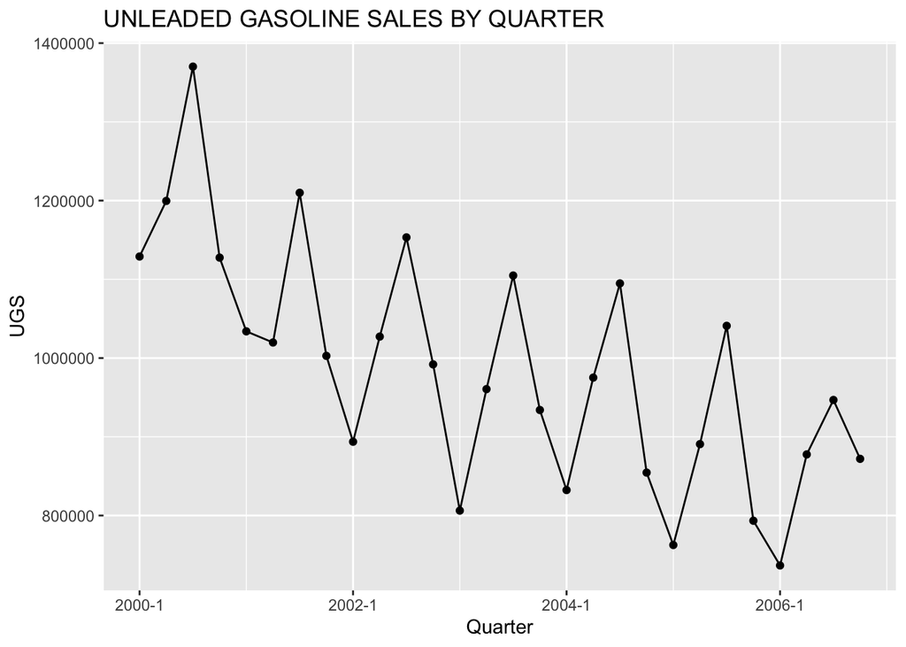

As one can see, the data is clearly not stationary. There is a decreasing trend and a strong seasonality. First quarters are always having lower consumption than yearly average and in third quarters the consumption increases sharply.

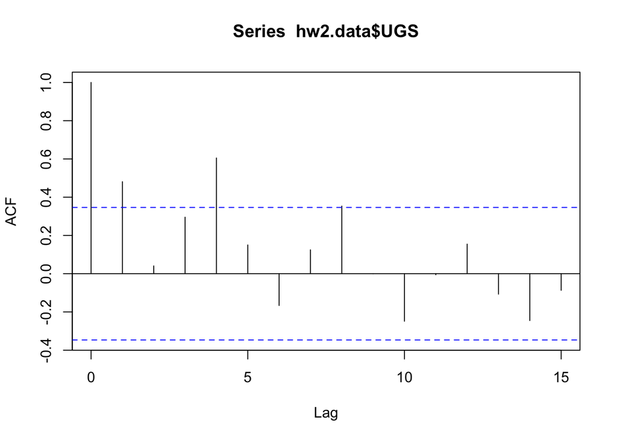

As one can see, first and fourth lags are passing over the ACF limit. Eight lag is passing over the threshold as well, albeit incrementally.

```r
hw2.data$trend <-1:32
hw2.data$QuarterlySeasonality <- rep(1:4,8)
hw2.data$lagged_1 <- c(NA,hw2.data$UGS[1:31])
hw2.data$lagged_4 <- c(rep(NA,4),hw2.data$UGS[1:28])
hw2.data$lagged_8 <- c(rep(NA,8),hw2.data$UGS[1:24])
```

Trend and seasonality have been defined as well as lagged values of UGS. 1,4,8 lags are of interest as mentioned above.

```r
lm1 <- lm(UGS~.,hw2.data)
summary(lm1)
```

```
##
## Call:
## lm(formula = UGS ~ ., data = hw2.data)
##
## Residuals:
##      9     10     11     12     13     14     15     16     17     18     19
##  -1112  -2209  -4018  -1038  18982 -15636  -5038  16659  12626  -2691   1474
##     20     21     22     23     24     25     26     27     28
## -21606 -10294   3065  38832 -22600 -19798  14889 -27296  26809
##
## Coefficients: (1 not defined because of singularities)
##                        Estimate Std. Error t value Pr(>|t|)
## (Intercept)           6.654e+08  6.903e+08   0.964    0.379
## Quarter              -3.329e+05  3.469e+05  -0.960    0.381
## RNUV                 -4.124e+06  5.061e+06  -0.815    0.452
## NLPG                  5.274e-01  6.986e-01   0.755    0.484
## PU                   -1.071e+03  3.880e+03  -0.276    0.793
## PG                    1.395e+03  5.560e+03   0.251    0.812
## NUGV                  4.801e-01  1.541e+00   0.311    0.768
## NDGV                 -1.161e+03  1.406e+04  -0.083    0.937
## GNPA                 -2.441e-02  5.087e-02  -0.480    0.652
## GNPC                 -2.557e-02  1.786e-01  -0.143    0.892
## GNP                   5.827e-02  5.424e-02   1.074    0.332
## trend                        NA         NA      NA       NA
## QuarterlySeasonality  3.532e+04  6.519e+04   0.542    0.611
## lagged_1             -1.081e+00  5.865e-01  -1.843    0.125
## lagged_4             -2.517e-01  4.192e-01  -0.601    0.574
## lagged_8             -2.230e-01  7.883e-01  -0.283    0.789
##
## Residual standard error: 33990 on 5 degrees of freedom
##   (12 observations deleted due to missingness)
## Multiple R-squared:  0.9778, Adjusted R-squared:  0.9155
## F-statistic: 15.71 on 14 and 5 DF,  p-value: 0.003337
```

[output not shown]

[figure not shown]

```r
ggpairs(hw2.data[,2:16])
```

```r
lm2 <- lm(UGS~NLPG+PU+PG+NUGV+NDGV+GNPA+lagged_1+lagged_4+lagged_8,hw2.data)
summary(lm2)
```

```
##
## Call:
## lm(formula = UGS ~ NLPG + PU + PG + NUGV + NDGV + GNPA + lagged_1 +
##     lagged_4 + lagged_8, data = hw2.data)
##
## Residuals:
##    Min     1Q Median     3Q    Max
## -70340 -22602  -2664  22472  86720
##
## Coefficients:
##               Estimate Std. Error t value Pr(>|t|)
## (Intercept)  1.293e+05  1.187e+06   0.109    0.915
## NLPG         1.070e-01  1.822e-01   0.587    0.570
## PU           7.039e+02  2.403e+03   0.293    0.776
## PG          -1.500e+03  2.992e+03  -0.501    0.627
## NUGV         2.857e-01  7.989e-01   0.358    0.728
## NDGV        -4.272e+03  1.152e+04  -0.371    0.719
## GNPA         1.142e-02  1.371e-02   0.833    0.424
## lagged_1    -9.692e-02  1.257e-01  -0.771    0.458
## lagged_4     2.566e-01  4.294e-01   0.598    0.563
## lagged_8     4.651e-01  3.964e-01   1.173    0.268
##
## Residual standard error: 52850 on 10 degrees of freedom
##   (12 observations deleted due to missingness)
## Multiple R-squared:  0.8926, Adjusted R-squared:  0.7959
## F-statistic:  9.23 on 9 and 10 DF,  p-value: 0.0008824
```

```r
lm3 <- lm(UGS~GNPA+lagged_4+trend,hw2.data)
summary(lm3)
```

```
##
## Call:
## lm(formula = UGS ~ GNPA + lagged_4 + trend, data = hw2.data)
##
## Residuals:
##    Min     1Q Median     3Q    Max
## -61033 -36361     70  21871  76343
##
## Coefficients:
##               Estimate Std. Error t value Pr(>|t|)
## (Intercept)  4.394e+05  1.977e+05   2.223  0.03793 *
## GNPA         1.828e-02  8.486e-03   2.155  0.04355 *
## lagged_4     5.063e-01  1.710e-01   2.961  0.00772 **
## trend       -3.080e+03  3.003e+03  -1.026  0.31735
## ---
## Signif. codes:  0 '***' 0.001 '**' 0.01 '*' 0.05 '.' 0.1 ' ' 1
##
## Residual standard error: 45920 on 20 degrees of freedom
##   (8 observations deleted due to missingness)
## Multiple R-squared:  0.8803, Adjusted R-squared:  0.8623
## F-statistic: 49.03 on 3 and 20 DF,  p-value: 2.109e-09
```

```r
lm4 <- lm(UGS~GNPA+lagged_1+lagged_4+lagged_8,hw2.data)
summary(lm4)
```

```
##
## Call:
## lm(formula = UGS ~ GNPA + lagged_1 + lagged_4 + lagged_8, data = hw2.data)
##
## Residuals:
##    Min     1Q Median     3Q    Max
## -70536 -30462   2141  36047  81570
##
## Coefficients:
##               Estimate Std. Error t value Pr(>|t|)
## (Intercept)  2.262e+05  1.379e+05   1.641    0.122
## GNPA         9.504e-03  6.979e-03   1.362    0.193
## lagged_1    -6.319e-02  1.027e-01  -0.615    0.547
## lagged_4     4.271e-01  2.699e-01   1.582    0.134
## lagged_8     3.081e-01  2.141e-01   1.439    0.171
##
## Residual standard error: 48380 on 15 degrees of freedom
##   (12 observations deleted due to missingness)
## Multiple R-squared:  0.8649, Adjusted R-squared:  0.8289
## F-statistic: 24.02 on 4 and 15 DF,  p-value: 2.256e-06
```

```r
lm5 <- lm(UGS~GNPA+PU+lagged_4,hw2.data)
summary(lm5)
```

```
##
## Call:
## lm(formula = UGS ~ GNPA + PU + lagged_4, data = hw2.data)
##
## Residuals:
##    Min     1Q Median     3Q    Max
## -70406 -26939  -5046  22108  85019
##
## Coefficients:
##               Estimate Std. Error t value Pr(>|t|)
## (Intercept)  5.515e+05  1.577e+05   3.496  0.00228 **
## GNPA         1.655e-02  5.354e-03   3.091  0.00576 **
## PU          -4.499e+02  2.137e+02  -2.105  0.04816 *
## lagged_4     5.836e-01  8.125e-02   7.182 5.92e-07 ***
## ---
## Signif. codes:  0 '***' 0.001 '**' 0.01 '*' 0.05 '.' 0.1 ' ' 1
##
## Residual standard error: 42630 on 20 degrees of freedom
##   (8 observations deleted due to missingness)
## Multiple R-squared:  0.8969, Adjusted R-squared:  0.8814
## F-statistic: 57.97 on 3 and 20 DF,  p-value: 4.8e-10
```

```r
lm6 <- lm(UGS~GNPA+PU+lagged_4+NLPG+NUGV,hw2.data)
summary(lm6)
```

```
##
## Call:
## lm(formula = UGS ~ GNPA + PU + lagged_4 + NLPG + NUGV, data = hw2.data)
##
## Residuals:
##    Min     1Q Median     3Q    Max
## -73472 -24939  -3890  24991  82885
##
## Coefficients:
##               Estimate Std. Error t value Pr(>|t|)
## (Intercept)  4.625e+05  4.735e+05   0.977 0.341687
## GNPA         1.710e-02  7.071e-03   2.418 0.026410 *
## PU          -4.620e+02  2.775e+02  -1.665 0.113201
## lagged_4     5.699e-01  1.408e-01   4.047 0.000756 ***
## NLPG        -3.220e-02  1.013e-01  -0.318 0.754272
## NUGV         2.826e-02  1.065e-01   0.265 0.793844
## ---
## Signif. codes:  0 '***' 0.001 '**' 0.01 '*' 0.05 '.' 0.1 ' ' 1
##
## Residual standard error: 44810 on 18 degrees of freedom
##   (8 observations deleted due to missingness)
## Multiple R-squared:  0.8974, Adjusted R-squared:  0.869
## F-statistic:  31.5 on 5 and 18 DF,  p-value: 2.677e-08
```

```r
lm7 <- lm(UGS~GNPA+PU+lagged_4+NUGV,hw2.data)
summary(lm7)
```

```
##
## Call:
## lm(formula = UGS ~ GNPA + PU + lagged_4 + NUGV, data = hw2.data)
##
## Residuals:
##    Min     1Q Median     3Q    Max
## -71206 -27041  -5197  22507  85356
##
## Coefficients:
##               Estimate Std. Error t value Pr(>|t|)
## (Intercept)  5.334e+05  4.077e+05   1.308 0.206356
## GNPA         1.638e-02  6.537e-03   2.506 0.021481 *
## PU          -4.575e+02  2.705e+02  -1.692 0.107060
## lagged_4     5.881e-01  1.256e-01   4.683 0.000162 ***
## NUGV         3.413e-03  7.066e-02   0.048 0.961983
## ---
## Signif. codes:  0 '***' 0.001 '**' 0.01 '*' 0.05 '.' 0.1 ' ' 1
##
## Residual standard error: 43730 on 19 degrees of freedom
##   (8 observations deleted due to missingness)
## Multiple R-squared:  0.8969, Adjusted R-squared:  0.8752
## F-statistic: 41.31 on 4 and 19 DF,  p-value: 4.035e-09
```

```r
lm8 <- lm(UGS~GNPA+PU+lagged_4+PG,hw2.data)
summary(lm8)
```

```
##
## Call:
## lm(formula = UGS ~ GNPA + PU + lagged_4 + PG, data = hw2.data)
##
## Residuals:
##    Min     1Q Median     3Q    Max
## -69198 -25988  -4974  21654  80365
##
## Coefficients:
##               Estimate Std. Error t value Pr(>|t|)
## (Intercept)  5.754e+05  1.860e+05   3.093  0.00598 **
## GNPA         1.793e-02  7.636e-03   2.348  0.02986 *
## PU          -1.108e+02  1.326e+03  -0.084  0.93431
## lagged_4     5.517e-01  1.482e-01   3.722  0.00145 **
## PG          -4.297e+02  1.657e+03  -0.259  0.79820
## ---
## Signif. codes:  0 '***' 0.001 '**' 0.01 '*' 0.05 '.' 0.1 ' ' 1
##
## Residual standard error: 43660 on 19 degrees of freedom
##   (8 observations deleted due to missingness)
## Multiple R-squared:  0.8972, Adjusted R-squared:  0.8756
## F-statistic: 41.47 on 4 and 19 DF,  p-value: 3.908e-09
```

Eight models have been identified. Briefly, first one includes every regressor, trend and seasonality defined. Second one includes every regressor that was significant in relation to UGS, when ggpairs() was checked. For the other ones only the ones that were the most correlated have been checked. After all these the fifth model whose regressors include GNPA,PU and lagged_4 have been selected, since it has the second highest adjusted R^2 and all its regressors were significant. The highest adjusted R^2 was with the first model, however it used many regressors some of which are not in relation with UGS, which will make good predictions about the future. As we know, using spruious regressors may increse our adjusted R^2 but they are not reliable predictors.

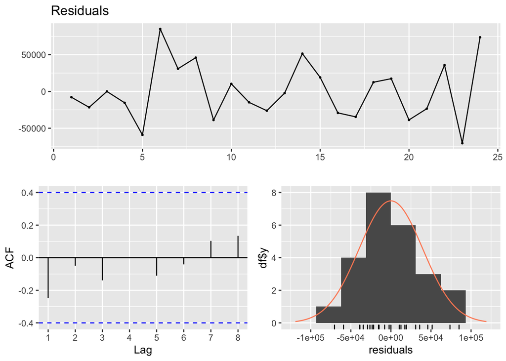

```
##
##  Breusch-Godfrey test for serial correlation of order up to 7
##
## data:  Residuals
## LM test = 6.3554, df = 7, p-value = 0.4989
```

The residuals seem random. The ACF also shows that they are not autocorrelated. They also seem like their mean is zero and Breusch-Godfrey test yields a p-value = 0.4989, which result in an inability to reject null hypothesis. Besides the variance of residuals are not increasing over time. All these observations increases the confidence to claim that our residuals are stationary.

```r
hw2.data[,predicted:=predict(lm5,hw2.data)]
hw2.data[,residual:=UGS-predicted]
hw2.data$predicted[28:32]
```

```
## [1] 798301.4 745774.4 835319.2 967867.5 846075.0
```

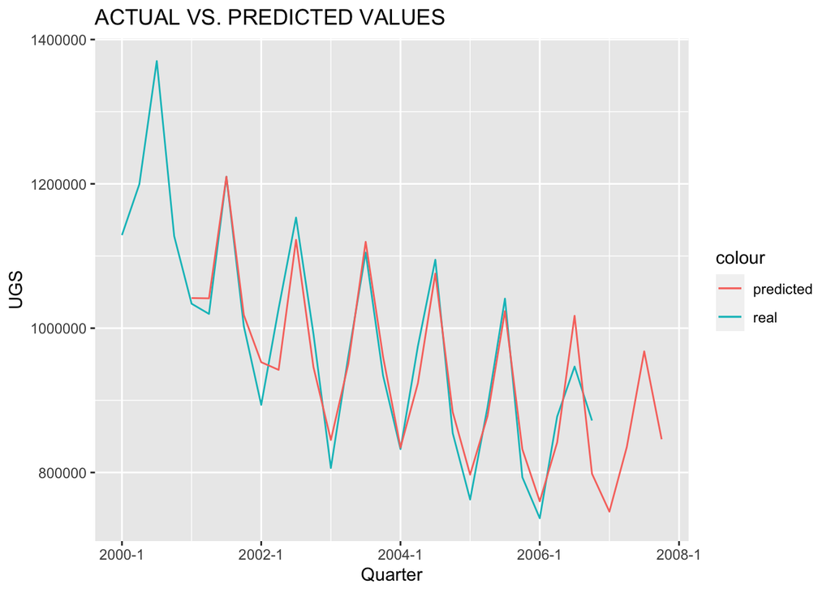